# Bruhn_A11_4

A11.28 モーメント分配法

$$M_{\text{fixed end}} = \frac{6EId}{L^2(2\beta-\alpha)}$$

ここで、 $K = \frac{I}{L}$ および $R = \frac{d}{L}$ とすると、

$$M = \frac{6KER}{2\beta-\alpha}$$

である。

Fig. A11.56 は、 $\frac{L}{j}$ に対する $2\beta-\alpha$ のプロットを示している。  
部材 BC について：

$$R = \frac{.202}{40} = .00505 \quad K = \frac{I}{L} = .0083$$

$$\frac{L}{j} = 2.12 \text{ に対して } 2\beta-\alpha = 1.08$$

したがって、節 C の移動による固定端モーメントは次のように等しくなる。

$$M_{BC} = M_{CB} = \frac{6 \times .0083 \times .00505 \times 29,000,000}{1.08} = -6750 \text{''\#}$$

部材 AC について：

$$R = \frac{.207}{47.2} = .00438 \quad K = .0029$$

$\frac{L}{j} = 2.42$ で、部材が引張状態のとき、 $2\beta-\alpha = .92$ 。  
したがって、

$$M_{AC} = M_{CA} = \frac{6 \times .00438 \times .0029 \times 29,000,000}{.92} = -2400 \text{''\#}$$

符号がマイナスなのは、目視によりモーメントが部材の端部を反時計回りに回転させる傾向があることが示されるためである（節 A11.2 参照）。

Fig. A11.65 は、これらのモーメントに対するモーメント分配を示している。B におけるモーメントの大きさは Fig. A11.63 の 6.7 パーセント、節 C においては 10.4 パーセントであるが、この例では緩和されている。

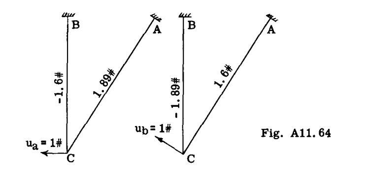

Fig. A11.64

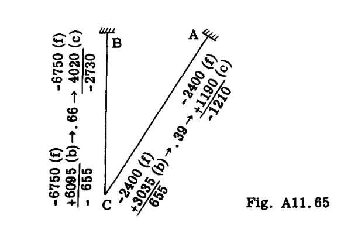

Fig. A11.65

## A11.15 剛節点を持つトラスの二次曲げモーメント *

航空機の構造設計では、剛節点を持つトラスがよく使用される。剛節点は、トラスの節点において部材同士を溶接するか、または各部材にボルトやリベットで固定されたガセットプレートを使用することによって生じる。荷重下でトラスが曲がると、トラスの節点はさまざまな量の移動またはたわみを経る。トラス部材は節点で剛に保持されているため、どのような節点の変位もトラス部材を曲げる傾向がある。トラス節点のたわみによってトラス部材に発生する曲げモーメントは一般に二次モーメントと呼ばれ、これらのモーメントによって発生する応力は二次応力と呼ばれる。

航空機の構造設計において疲労強度がより重要になってきているため、二次応力の問題は過去よりも重要性を増している。モーメント分配法は、トラスのたわみによるトラス部材のこれらの二次モーメントを決定するためのシンプルで迅速な方法を提供する。一般的な手順は次のとおりである。

1. 臨界設計条件による各トラス節点の水平および垂直変位を求める（トラスのたわみを求める方法については、第 A7 章を参照）。
2. これらの変位から、各トラス部材について、部材の一端の他端に対する横方向たわみを求めることができる。
3. これらの横方向変位による各部材の固定端モーメントを計算する。
4. 各トラス部材の剛性係数とキャリーオーバー（到達）係数を計算する。
5. 各トラス節点の分配係数を計算する。
6. モーメント分配プロセスを実行して、各部材の端部における二次モーメントを求める。
7. これらの二次モーメントによる応力を計算し、ピン接合トラス作用によるトラス部材の一次軸応力と結合する。

## A11.16 曲線部材を持つ構造物

モーメント分配法は、直線部材だけでなく曲線部材も含む連続構造物に適用することができる。直線部材の剛性係数、キャリーオーバー係数、および固定端モーメントを求めるための式は、曲線部材には使用できない。第 A9 章で提示されている弾性中心法は、これらの曲線部材の値を決定するための迅速かつシンプルな方法を提供する。剛性係数とキャリーオーバー係数の値を決定する際のエラスティックセンター（弾性中心）法の使用について、以下に説明する。

- 第 C2 章、パート H も参照。

## A11.17 曲線部材を持つ構造物

第 A9 章で説明されているように、全モーメント重量 $\phi$ は $\frac{M}{EI}$ 図の面積に等しい。したがって、Fig. A11.68 の $\frac{M}{EI}$ 図における $\phi$ は、次のように等しくなる。

$$-\frac{4}{L}\left(\frac{L}{2}\right) + \frac{2}{L}\left(\frac{L}{2}\right) = -2 + 1 = -1$$

換言すれば、全弾性モーメント重量 $\phi$ は 1 または単位量に等しい。

この全モーメント重量 $\phi$ の位置は、 $\frac{M}{EI}$ 図の図心と一致する。したがって、B からこの図心までの距離 $\bar{x}$ を求めるために、B の周りの $\frac{M}{EI}$ 図のモーメントをとり、 $\frac{M}{EI}$ 図の全面積 $\phi$ で割る。これにより、

$$\bar{x} = \frac{-2(.667L) + 1(.333L)}{-2 + 1} = \frac{-L}{-1} = L$$

したがって、1 に等しい全モーメント重量 $\phi$ の図心は、点 A、すなわち B の左側距離 $L$ の位置にある。

直線梁の剛性とキャリーオーバー係数を決定するために弾性中心法を使用する際、A に加えられたモーメントによる曲げモーメント曲線は、端部 A を 1 ラジアンの角度だけ回転させるような大きさであると仮定する。上述のように、この荷重に対するモーメント重量 $\phi$ は 1（単位量）であり、その図心位置は A にある。次に、弾性中心法によって、端部 A を回転ゼロに戻すために必要なモーメントを求める。A におけるこのモーメントの値は、梁 AB の剛性係数に等しくなる。不静定力を簡単にするために、弾性中心法はそれらを弾性中心に基準化する。第 A9 章から、一つの軸に対して対称な構造物の弾性中心における不静定力の式は次のとおりである。

$$M_o = \frac{-\sum \phi_s}{\sum ds/EI} \quad \text{--- (1)}$$

$$Y_o = \frac{-\sum \phi_s X}{I_y} \quad \text{--- (2)}$$

$$X_o = \frac{\sum \phi_s Y}{I_x} \quad \text{--- (3)}$$

Fig. A11.69 は、Fig. A11.66 の梁を、端部 A における反力が、梁の弾性中心である点 (O) で終端する剛なブラケットに置き換えられた梁に置き換えたものである。梁の対称性により、弾性中心は梁の中点にある。弾性モーメント荷重は $\phi_s = 1$ であり、その位置は Fig. A11.69 に示すように A にある。

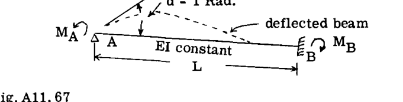

Fig. A11.66

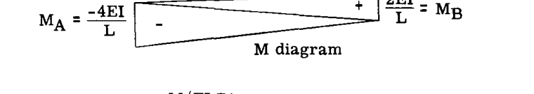

Fig. A11.67

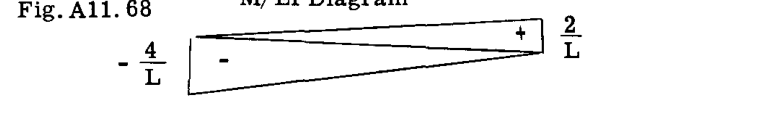

Fig. A11.68

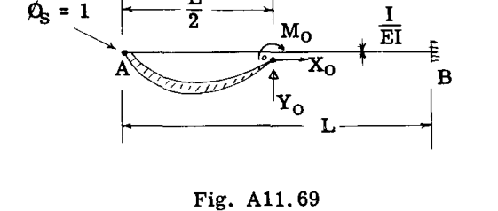

Fig. A11.69

式 (1)、(2)、および (3) によって (O) における不静定量について解く。

$$M_o = \frac{-\phi_s}{\sum ds/EI} = \frac{-1}{L/EI} = -\frac{EI}{L}$$

$$Y_o = \frac{-\sum \phi_s x}{I_y} = \frac{-1(-\frac{L}{2})}{\frac{1}{12} \frac{1}{EI} L^3} = \frac{6EI}{L^2}$$

$$X_o = \frac{\sum \phi_s y}{I_x} = 0 \quad (\text{弾性中心 (O) を通る x 軸に対する } \phi_s \text{ 荷重の垂直距離 y がゼロであるため})$$

Fig. A11.70 は、弾性中心に作用するこれらの力を示している。

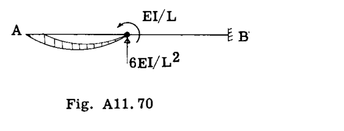

Fig. A11.70

端部 A における曲げモーメントは次のように等しくなる。

$$-\frac{EI}{L} - \frac{6EI}{L^2}\left(\frac{L}{2}\right) = -\frac{4EI}{L}$$

定義により、剛性係数は、端部 A を 1 ラジアンの角度だけ回転させるために必要な A におけるモーメントである。したがって、 $\frac{4EI}{L}$ が剛性係数であり、この結果は節 A11.4 で以前に導出された値と一致する。

Fig. A11.70 の B における曲げモーメントは次のように等しくなる。

$$-\frac{EI}{L} + \frac{6EI}{L^2}\left(\frac{L}{2}\right) = \frac{2EI}{L}$$

したがって、A から B へのキャリーオーバー係数は .5 であり、キャリーオーバーモーメントは A におけるモーメントの符号と反対になる。

## A11.18 曲線部材の剛性とキャリーオーバー（到達）係数

Fig. A11.71 は曲線部材、すなわち一定の $EI$ 断面を持つ半円弧を示している。端部 B は固定され、端部 A は単純支持されている。Fig. A11.71 に示すように、端部 A に、A において 1 ラジアンの回転を生じさせるような大きさのモーメント $M_A$ が加えられる。Fig. A11.72 は不静定である曲げモーメント曲線の一般的な形状を示している。Fig. A11.73 では、A における支持が取り除かれ、端部 A は構造物の弾性中心で終端する剛なブラケットによって接続されている。ここで、Fig. A11.71 で仮定された A における単位回転を相殺するために、(O) に必要な力を求める。

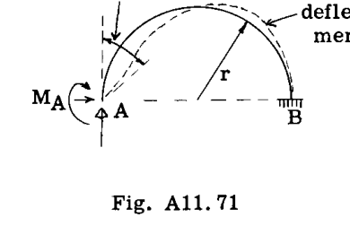

Fig. A11.71

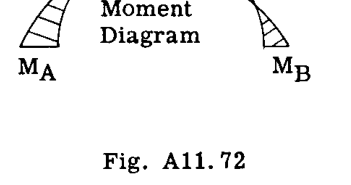

Fig. A11.72

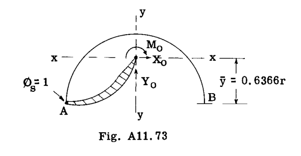

Fig. A11.73

Fig. A11.72 の曲線の $\frac{M}{EI}$ 曲線の全面積は、直線部材について詳細に説明したように、計算すると 1 または単位量に等しくなる。この $\frac{M}{EI}$ 図の図心は、計算すると点 A に位置する。したがって、Fig. A11.73 において、A に単位 $\phi_s$ 荷重を適用し、O における不静定力を求める。垂直軸または y 軸に対する構造物の対称性により、弾性中心はこの対称軸上にある。基準線 AB から弾性中心までの垂直距離は、 $\bar{y} = .6366r$ に等しくなる（第 A3 章の A3.4 ページを参照）。

弾性慣性モーメント $I_x$ および $I_y$ は計算するか、または A3.4 ページの表などの参考資料から取得することができる。  
これより、

$$I_x = .2978r^3t \quad \text{ただし } t = \frac{1}{EI}$$

したがって、

$$I_x = \frac{.2978r^3}{EI}$$

$$I_y = \frac{\pi r^3 t}{2} = \frac{\pi r^3}{2EI}$$

$\phi_s = 1$ であり、点 A に位置していることを念頭に置いて、(O) における不静定力の式を解く。

$$M_o = -\frac{\sum \phi_s}{\sum ds/EI} = \frac{-(1)}{\frac{\pi r}{EI}} = -\frac{EI}{\pi r}$$

$$Y_o = -\frac{\sum \phi_s x}{I_y} = -\frac{(1)(-r)}{\frac{\pi r^3}{2EI}} = \frac{2EI}{\pi r^2}$$

$$X_o = \frac{\sum \phi_s y}{I_x} = \frac{(1)(-.6366r)}{\frac{0.2978r^3}{EI}} = -2.14\frac{EI}{r^2}$$

Fig. A11.74 は、弾性中心に作用するこれらの力を示している。遠端 B で固定され近端 A で単純支持された曲線梁の剛性係数に等しい、A における曲げモーメントは次のように求められる。

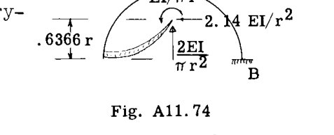

Fig. A11.74

A における曲げモーメント：

$$M_A = \frac{-EI}{\pi r} - 2.14\frac{EI}{r^2}(0.6366r) - \left(\frac{2EI}{\pi r^2}\right)r$$

$$= \frac{-0.318EI}{r} - \frac{1.36EI}{r} - 0.636\frac{EI}{r} = -2.314\frac{EI}{r}$$

B における曲げモーメント：

$$M_B = \frac{-0.318EI}{r} - \frac{1.36EI}{r} + \frac{0.636EI}{r} = -1.042\frac{EI}{r}$$

## 固定端モーメント

任意の外部荷重に対する曲線部材の固定端モーメントは、第 A9 章に示されているように、弾性中心法によって非常に迅速に決定できるため、ここでの説明は繰り返さない。

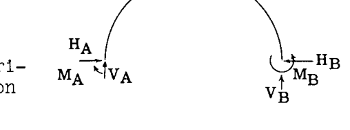

Fig. A11.75

学生は、連続構造物中の直線部材の端部モーメントがモーメント分配プロセスから求められると、残りの端部力は静定になるが、連続構造物中の曲線部材の場合、端部モーメントを知るだけでは曲線部材は静定にならないことを認識または理解すべきである。なぜなら、Fig. A11.75 に示すように 2 つの支持部に 6 つの未知数があり、静定方程式は 3 つしかないからである。モーメント分配プロセスから端部モーメントが決定された場合でも、依然として 1 つの未知数、すなわち梁端部の 1 つにおける水平反力が残る。この残された不静定力をどのように処理するかの方法は、いくつかの例題の解法を提示することによって最もよく説明できる。

## A11.19 例題。曲線部材を含む連続構造物。

### 例題 1

Fig. A11.76 は、直線部材と曲線部材の両方からなるフレームを示している。形状は簡略化されているが、このフレームは、客室天井の上の設備を支持するために A と C の間に 1 つ、客室床荷重を支持するために F と D の間にもう 1 つの 2 つの横方向部材を持つ、胴体フレームをある程度代表している。フレームを支持する力は、側部材の矢印で示されているように、胴体外板によって提供されると仮定される。フレーム部材の図心軸に対するこれらの外板支持力の偏心は、この簡略化された例題では無視される。なぜなら、この例題の主な目的は、曲線部材を含む連続構造物の解決へのモーメント分配法の適用を説明することだからである。

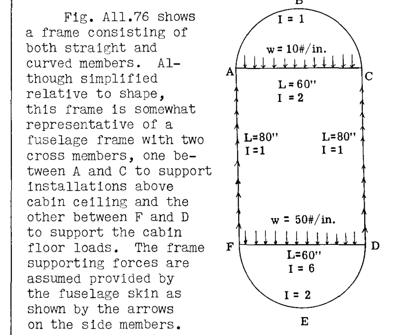

Fig. A11.76

### 解答

構造と荷重の対称性により、フレームの横揺れによるフレーム節点の移動は発生しない。

フレームの横方向部材 AC および FD は、2 つのアーチの曲げによる節点 A、C、F、および D の水平移動を防ぐ。軸変形によるこれらの節点の水平移動は、通常、フレーム部材の曲げを引き起こすことと比較してそれほど重要ではない。したがって、フレーム節点は回転のみを被ると仮定することができ、したがってモーメント分配法が直接適用可能である。

フレームの各部材の剛性 (K) 値の計算：

上部曲線部材 ABC：

$$K_{ABC} = K_{CBA} = 2.314\frac{EI}{r}$$

この値は、前節 A11.18 で導出された。

代入すると：

$$K_{ABC} = K_{CBA} = \frac{2.314 \times 1}{30} = .0770 \quad (E \text{ は一定であるため、} K \text{ 値には相対値のみが必要であるため省略する。})$$

各フレーム部材の断面の相対慣性モーメントは Fig. A11.76 に示されている。

$$K_{FED} = K_{DEF} = \frac{2.314 \times 2}{30} = .1540$$

すべての直線部材について、剛性係数は $\frac{4EI}{L}$ に等しい。したがって、

$$K_{AC} = K_{CA} = 4 \times \frac{2}{60} = 0.1333$$

$$K_{FD} = K_{DF} = 4 \times \frac{6}{60} = 0.4000$$

$$K_{AF} = K_{FA} = 4 \times \frac{1}{80} = 0.0500$$

$$K_{CD} = K_{DC} = 4 \times \frac{1}{80} = 0.0500$$

各節点における分配係数：

#### 節点 A

$$\sum K = 0.1333 + .0770 + .0500 = 0.2603$$

$D$ を分配係数の記号とする。

$$D_{ABC} = \frac{.0770}{0.2603} = 0.296$$

$$D_{AC} = \frac{.1333}{0.2603} = 0.512$$

$$D_{AF} = \frac{.0500}{0.2603} = 0.192$$

#### 節点 F

$$\sum K = .0500 + 0.400 + 0.1540 = 0.6040$$

$$D_{FA} = \frac{.0500}{.6040} = .082$$

$$D_{FD} = \frac{.4000}{.6040} = .663$$

$$D_{FED} = \frac{.1540}{.6040} = .255$$

#### キャリーオーバー（到達）係数：

直線部材の場合、キャリーオーバー係数は 0.5 であり、この章で採用されている符号慣行を使用する場合、モーメントの符号は分配モーメントと同じである。

一定の $I$ を持つ半円形アーチの場合、キャリーオーバー係数は前節で導出され、0.452 であることがわかった。このキャリーオーバーモーメントの符号は、梁の他端における分配モーメントと同じ符号であった。しかし、本書でモーメント分配に採用されている符号慣行を使用すると、キャリーオーバー係数はマイナス、すなわち分配モーメントと反対の符号になる。

#### 固定端モーメントの計算

フレームの曲線部材には外部荷重が適用されていないため、曲線部材の固定端モーメントはゼロである。

部材 AC について、固定端モーメントは $\frac{WL^2}{12} = \frac{10 \times 60^2}{12} = 3000 \text{ in. lb.}$ に等しく、部材 FD については $\frac{50 \times 60^2}{12} = 15000 \text{ in. lb.}$ である。

側部材の支持外板力はフレーム部材の重心線に沿って作用すると仮定されているため、部材 AF および CD の固定端モーメントはゼロである。

#### モーメント分配プロセス：

Fig. A11.77 は、モーメント分配プロセスの連続するサイクルを実行する際の計算を示している。フレームと荷重の対称性により、プロセスはフレームの半分に対してのみ実行すればよいため、Fig. A11.77 では節点 A と F のみが考慮されている。なぜなら、D と C における数値結果は、それぞれ A と F と同じになるからである。図では、分配係数は各節点に箱で示されている。プロセスは、各部材の端部における符号に注意して固定端モーメントを配置することから開始される。すなわち、AC で -3000、CA で 3000、FD で -15000、DF で 15000 である。ここで節点 A のロックを解除すると、-3000 の不釣り合いモーメントが見つかり、これは静的バランスのためにプラス 3000 が必要であることを意味する。したがって、節点 A は、.512 × 3000 = 1536 を AC に、.296 × 3000 = 880 を ABC に、および .192 × 3000 = 576 を AF に分配することによってバランスされる。その後、これらの分配された各値の下に短い水平線が引かれ、これらがバランスモーメントであることを示す。キャリーオーバーモーメントは、節点 F にキャリーオーバーすることにより、直ちに対処される。 .5 × 576 = 288。A から C へのキャリーオーバーモーメントは .5 × 1536 = 768 となり、したがって C から A へのキャリーオーバーは .5(-1536) = -768 となり、図に示すように A に記録される。アーチ部材 ABC について、A から C へのキャリーオーバーモーメントは -0.452 × 880 = -401（図示せず）となり、したがって C から A へのキャリーオーバーは、アーチ部材 CBA の図の節点 A に示すように、-0.452 × (-880) = 401 となる。図の節点 C は、学生がフレームの右側から左側に流れるキャリーオーバーモーメントの符号を理解するのを助ける目的で、一度バランスされている。

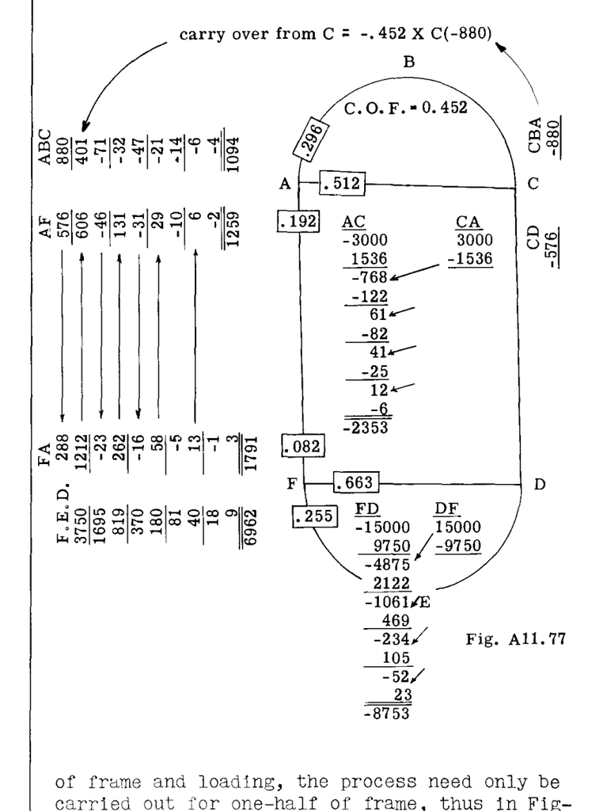

Fig. A11.77

節点 A をバランスさせ、キャリーオーバーモーメントに対処した後、A が再び固定されていると仮定し、節点 F に進む。ここで、-15000 + 288 = -14712 の不釣り合いモーメントが見つかり、したがってバランスのためにプラス 14712 が必要となる。バランス分配は、FED に .255 × 14712 = 3750、FD に .663 × 14712 = 9750、および FA に .082 × 14712 = 1212 である。キャリーオーバーモーメントは、A へ .5 × 1212 = 606、アーチ部材を経由して D から F へ .452 × 3750 = 1695、および部材 FD 上の D から -.5 × 9750 = -4875 である。ここで、キャリーオーバーモーメントによって不釣り合いになった節点 A に戻り、バランスとキャリーオーバーのサイクルを繰り返す。Fig. A11.77 に示す完全な解答では、各節点 A と F は 5 回バランスされた。各節点における部材端部の最終的な曲げモーメントは、二重の短い線の下に示されている。

アーチ部材 ABC は、各端 A と C に 3 つの未知の力、すなわち合計 6 つの未知数を持っている。3 つの静的平衡方程式に加えて、モーメント分配プロセスから求められた A と C における既知の端部モーメントの値があっても、アーチ部材は依然として 1 次不静定である。したがって、アーチ ABC の曲げモーメントを計算する前に、部材 AC の軸荷重によって提供される A または C における水平反力を求めなければならない。

この問題の最初のステップは、Fig. A11.78 に示すように、部材 ABC と AC からなるフレーム部分の弾性中心を見つけ、次に弾性中心を通る x 軸および y 軸に関する弾性慣性モーメントを求めることである。

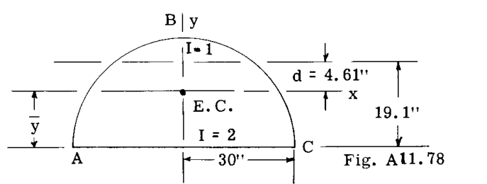

Fig. A11.78

$$\bar{y} = \frac{19.1 \times \pi (30/1)}{\frac{\pi \times 30}{1} + \frac{60}{2}} = 14.49\text{"}$$

（注：19.1 は、線 AC からアーチ部材 ABC の図心までの距離に等しい。）

慣性モーメント $I_x$ の計算：

部材 ABC：

$$I_x = \frac{.3r^3}{I} + \frac{\pi r d^2}{I}$$

$$= \frac{.3 \times 30^3}{1} + \frac{\pi \times 30}{1} \times 4.61^2 = 10100$$

部材 AC：

$$I_x = \frac{60}{2} \times 14.49^2 = 6310$$

$$I_x \text{ total} = 16410$$

構造物の全弾性重量は以下に等しい。  
$\sum ds/I = (\pi \times 30/1) + 60/2 = 124.24$

解法の次のステップは、Fig. A11.77 のモーメント分配プロセスによって求められた、部材 AC 上の与えられた荷重と端部モーメントによる、このフレーム部分の曲げモーメント図を描くことである。それは Fig. A11.79 に (1) から (3) とラベル付けされた 3 つの部分で構成されている。部分 (1) と (2) は端部モーメントによるものであり、部分 (3) は部材 AC 上の分配された横方向荷重によるものである。

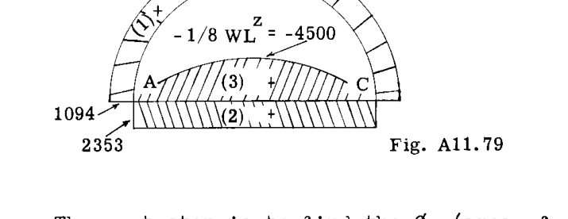

Fig. A11.79

次のステップは、各部分の $\phi_s$ （ $\frac{M}{I}$ 曲線の面積）とその図心位置を求めることである。

$$\phi_{s1} = 1094 \times \pi \times 30/1 = 103000$$

$$\phi_{s2} = 60 \times 2353/2 = 70590$$

$$\phi_{s3} = (-.667 \times 60 \times 4500)/2 = -90000$$

$$\sum \phi_s = 83590$$

Fig. A11.80 は、弾性中心を通る x 軸および y 軸を基準とし、それらの図心位置に集中した $\phi_s$ 値を示している。

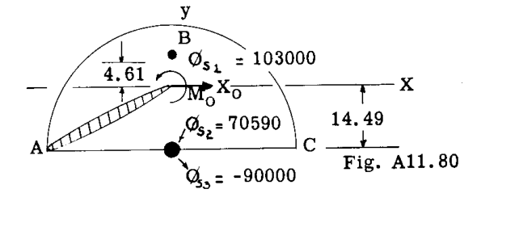

Fig. A11.80

フレームは A で切断され、A におけるアーチ端は弾性中心に剛なブラケットで接続されていると想定されている。A における切断面の相対的な移動を相殺する弾性中心における不静定量は、ここで計算することができる。

$$M_o = \frac{-\sum \phi_s}{\sum ds/I} = \frac{-83590}{124.24} = -673 \text{ in. lb.}$$

$$X_o = \frac{\sum \phi_s Y}{I_x} = [103000 (4.61) + 70590 (-14.49) - 90000 (-14.49)] / 16410 = 46 \text{ lb.}$$

$$Y_o = \frac{-\sum \phi_s x}{I_y} = 0 \quad (x = \text{ゼロであるため})$$

ABC または AC 上の任意の点における曲げモーメントは、 $M_o$ および $X_o$ によるものに Fig. A11.79 のモーメントを加えたものに等しくなる。

例えば、

部材 ABC 上の点 A において、

$$M_A = 1094 - 670 + 46 \times 14.49 = 1091 \quad (\text{Fig. A11.77 で求められたモーメントが正しいものであるため、1094 になるはずである。計算尺の精度によるわずかな誤差。})$$

部材 ABC 上の点 B において：

A における水平反力は部材 AC に曲げを生じさせないため、Fig. A11.79 の値が真のモーメントである。

Fig. A11.80 からの静力学による部材 AC の軸荷重は $X_o$ 、すなわち 46 lb. の引張荷重に等しい。部材 AC はまた、部材 FA および DC の上部における剪断反力による軸荷重も受ける。Fig. A11.81 は、Fig. A11.77 で求められた端部モーメントを持つ側部材 FA および DC の自由体を示している。

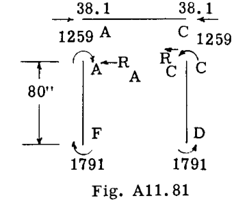

Fig. A11.81

A と C における剪断反力は、下端の周りのモーメントをとることによって求めることができる。したがって、FD について、

$$R_A = \frac{1259 + 1791}{80} = 38.1 \text{ lb.}$$

同様に、

$$R_C = 38.1 \text{ lb.}$$

これらの反力は、クロス部材 AC 上で反対方向に作用し、したがって部材 AC に 38.1 lb. の圧縮荷重を与え、これにアーチ反力からの 46 lb. の引張荷重を加えて、クロス部材の最終荷重を得る必要がある。

### 下部アーチ部材 FED の曲げモーメント

アーチ上の真の曲げモーメントを求める前に、アーチ FED における水平反力を求めなければならない。手順は上部アーチの場合と同じである。Fig. A11.81, 82, 83 は、下部フレーム部分の結果を示している。

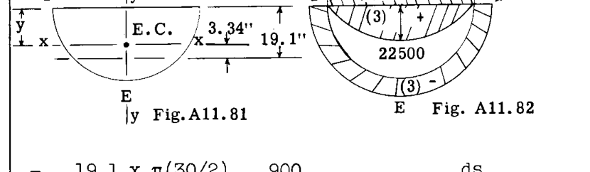

Fig. All.81, 82

$$\bar{y} = \frac{19.1 \times \pi(30/2)}{\frac{\pi \times 30}{2} + \frac{60}{6}} = \frac{900}{57.1} = 15.76\text{"}$$

$$\sum \frac{ds}{I} = 57.1$$

$$I_x = \frac{.3 \times 30^3}{2} + 15\pi \times 3.34^2 = 4578$$

$$\frac{(60/6)(15.76)^2 = 2478}{I_x = 7056}$$

Fig. A11.82 から、

$$\phi_{s1} = -8753 \times \frac{60}{6} = -87530$$

$$\phi_{s2} = .667 \times 22500 \times \frac{60}{6} = 150000$$

$$\phi_{s3} = -6962\pi \times \frac{30}{2} = -328000$$

$$\sum \phi_s = -265500$$

不静定力 $M_o$ および $X_o$ について解く（Fig. A11.83 参照）。

$$M_o = \frac{-\sum \phi_s}{\sum ds/I} = -\frac{(-265500)}{57.1} = 4650 \text{ in. lb.}$$

$$X_o = \frac{\sum \phi_s y}{I_x} = \frac{-87530 \times 15.76 + 150000 \times 15.76 - 328000(-3.34)}{7056}$$

$$X_o = 294 \text{ lb.}$$

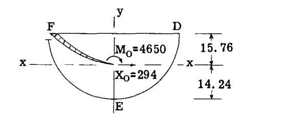

Fig. A11.83

部材 FED 上の F における曲げモーメント：

$$M_F = -6962 + 4650 - 294 \times 15.76 = -6962 \text{ in. lb.}$$

$$M_E = -6962 + 4650 + 294 \times 15.76 = 2340 \text{ in. lb.}$$

部材 FD における軸荷重 = 294 lb. の圧縮に、点 F と D における側部材からの剪断反力による 38.1 lbs. の引張を加えた、または結果として 255.9 lb. の圧縮荷重。Fig. A11.84 は、フレームの各部材における最終的な曲げモーメント図を示している。

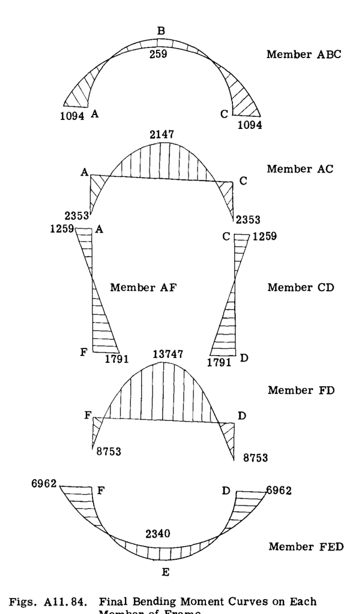

Figs. A11.84

### 例題 2. 曲線部材上の外部荷重。

Fig. A11.85 は、直線部材だけでなく曲線部材にも外部荷重が適用されているフレームを示している。フレームを支持する力は、側部材 AD および CE に沿って均一に作用すると仮定されている。問題は、フレームの点 ABCDE における曲げモーメントを決定することである。

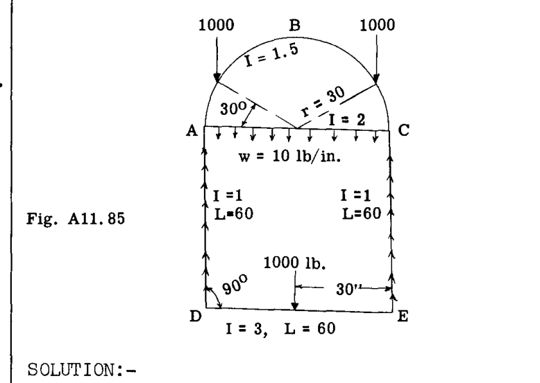

Fig. A11.85

### 解答：-

#### 剛性係数 K の計算

部材 ABC：

$$K_{ABC} = 2.314 \frac{I}{r} = 2.314 \times \frac{1.5}{30} = .1158$$

$$K_{AC} = 4\frac{I}{L} = 4 \times \frac{2}{60} = .1333$$

$$K_{AD} = 4\frac{I}{L} = 4 \times \frac{1}{60} = .0667$$

$$K_{DE} = 4\frac{I}{L} = 4 \times \frac{3}{60} = .2000$$

#### 分配係数 D の計算

##### 節点 A

$$\sum K = .1158 + .1333 + .0667 = .3158$$

$$D_{ABC} = \frac{.1158}{.3158} = .366$$

$$D_{AC} = \frac{.1333}{.3158} = .422$$

$$D_{AD} = \frac{.0667}{.3158} = .212$$

##### 節点 D

$$\sum K = .0667 + .2000 = .2667$$

$$D_{DA} = \frac{.0667}{.2667} = .25$$

$$D_{DE} = \frac{.2000}{.2667} = .75$$

ABC のキャリーオーバー係数は、半円弧について以前に導出されたように -0.452 であり、直線部材の場合は 0.5 である。

#### 固定端モーメントの計算

部材 AC について、

$$M_A = M_B = \frac{1}{12} wL^2 = \frac{1}{12} \times 10 \times 60^2 = 3000$$

DE について、

$$M_B = M_E = \frac{PL}{8} = 1000 \times \frac{60}{8} = 7500$$

曲線部材 ABC：

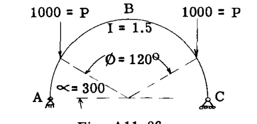

Fig. A11.86

Fig. A11.87 は、静的モーメント曲線の一般的な形状を示している。反力と荷重の間のフレーム部分について、曲げモーメント式は $M = P(r - r \cos \alpha)$ である。

2つの 1000 lb. 荷重の間の梁部分について、曲げモーメントは一定であり、 $M = P(r - r \cos 30^\circ)$ に等しい。

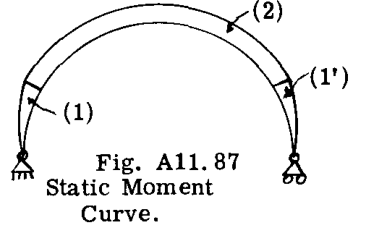

Fig. A11.87

#### $\phi_s$ 値の計算

$\phi_s$ 値は、 $M/I$ 曲線の面積に等しい。Fig. A11.87 のモーメント曲線は、(1)、(1’)、および (2) とラベル付けされた 3 つの部分に分割されている。

$$\phi_{s1} + \phi_{s2} = 2 \left[ \frac{Pr^2}{I} (\alpha - \sin \alpha) \right]$$

$$= 2 \left[ \frac{1000 \times 30^2}{1.5} (.524 - .5) \right] = 28800$$

線 AC から $\phi_{s1}$ および $\phi_{s2}$ 値の図心までの垂直距離 $\bar{y}$ は、

$$\bar{y} = \frac{r(1 - \cos \alpha - \frac{\sin^2 \alpha}{2})}{\alpha - \sin \alpha} = \frac{30(1 - .867 - 0.5/2)}{.524 - .5} = 10 \text{ in.}$$

$$\phi_{s2} = \frac{Pr^2\theta}{I} (1 - \cos \alpha) \quad \theta = 120^\circ, \alpha = 30^\circ$$

$$\phi_{s2} = \frac{1000 \times 30^2 \times 2.1}{1.5} (1 - .867) = 167300$$

線 AC から $\phi_{s2}$ の図心までの垂直距離 $\bar{y}$ は、

$$\bar{y} = \frac{2r \sin \theta/2}{\theta} = \frac{2 \times 30 \times 0.867}{2.1} = 24.8 \text{ in.}$$

Fig. A11.88 は、 $\phi_s$ 値と、アーチの弾性中心を通る x 軸および y 軸に関するそれらの位置を示している。

弾性中心法では、部材の全弾性重量と、弾性中心を通る軸に関するその弾性慣性モーメントが必要である。

$$\text{TOTAL ELASTIC WEIGHT} = \sum \frac{ds}{I} = \frac{\pi r}{1.5} = \frac{\pi \times 30}{1.5} = 62.83$$

線 AC からアーチ ABC の弾性中心までの距離 $\bar{y}$ は、 $0.6366r = .6366 \times 30 = 19.1 \text{ in.}$ である。  
$I_x = 0.2978r^3/I = .2978 \times 30^3/1.5 = 5350$

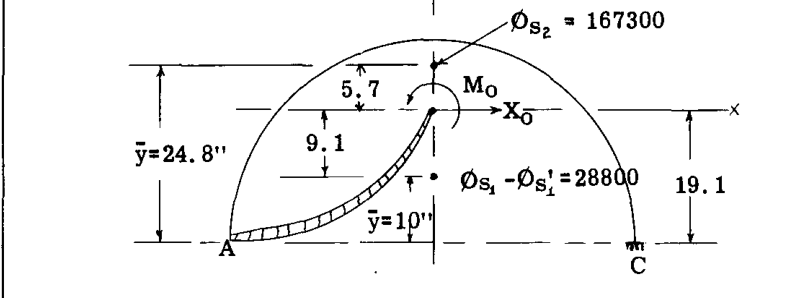

Fig. A11.88

弾性中心における不静定力の計算：

$$M_o = \frac{-\sum \phi_s}{\sum ds/I} = \frac{-(28800 + 167300)}{62.83} = -3122 \text{ in. lb.}$$

$$X_o = \frac{\sum \phi_s y}{I_x} = \frac{167300 \times 5.7 + 28800(-9.1)}{5350} = 129.3 \text{ lb.}$$

$$Y_o = -\frac{\sum \phi_s x}{I_y} = 0 \quad (x = 0 \text{ であるため})$$

A と C における静的モーメントはゼロと仮定されていたため、端部 A と C における固定端モーメントは、不静定力 $M_o$ および $Y_o$ によるモーメントに等しくなる。

$$M_A = M_C = M_o + X_o y = -3122 + 129.3(-19.1) = -652 \text{ in. lb.}$$

#### モーメント分配プロセス

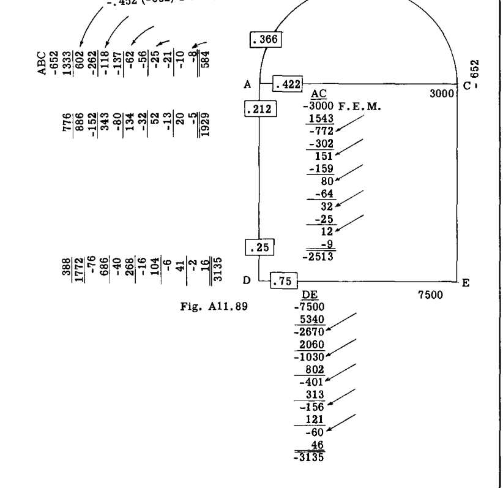

Fig. A11.89

キャリーオーバーモーメントは次のとおりである：

$$\text{E から D へ } = .5 \times (-5340) = -2670$$

$$\text{D から A へ } = .5 \times (1772) = 886$$

最初のサイクルが完了した。結果の合理的な精度を得るために、Fig. A11.89 においてさらに 5 サイクルが実行される。最終的な端部モーメントは、二重の短い線の下にリストされている。

アーチ部材 ABC について、584 の端部モーメントは正しい。しかし、アーチ上の他の任意の点における端部モーメントを求める前に、A におけるアーチ上の水平反力を決定しなければならない。この反力は弾性中心法によって決定される。

Fig. A11.90 は、5 つの部分 1 から 5 で構成される、部材 ABC および AC の曲げモーメント曲線を示している。

部材の $I$ で割った各モーメント曲線の面積に等しい $\phi_s$ 値の計算。

$$2\phi_{s1} = 28800$$

$$\phi_{s2} = 167300$$

$$\phi_{s3} = 584 \times \pi \times 30/1.5 = 36800$$

$$\phi_{s4} = -(.667 \times 4500 \times 60/2) = -90000$$

$$\phi_{s5} = 2513 \times 60/2 = 75390$$

$$\sum \phi_s = 218290$$

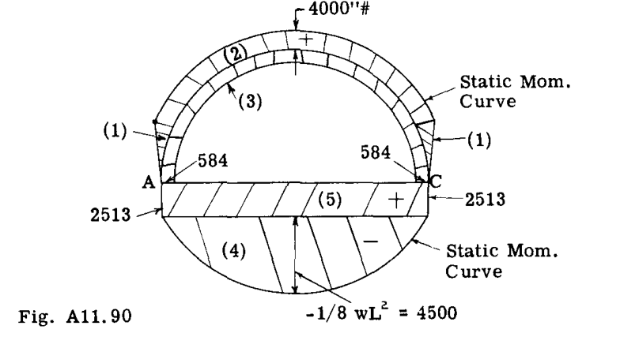

Fig. A11.90

弾性中心位置と $I_x$ の計算。

線 AC から弾性中心までの距離 $\bar{y}$ は、

$$\frac{19.1 \times \pi \times 30/1.5}{\frac{\pi \times 30}{1.5} + \frac{60}{2}} = \frac{1202}{92.83} = 12.97\text{"}$$

$$\text{TOTAL ELASTIC WEIGHT} = 92.83$$

$$I_x = \frac{.2978 \times 30^3}{1.5} + \frac{\pi \times 30}{1.5} (6.13)^2 + \frac{60}{2} \times 12.97^2 = 12713$$

Fig. A11.91 は、弾性中心位置と、それらの図心位置を合わせた $\phi_s$ 値を示している。

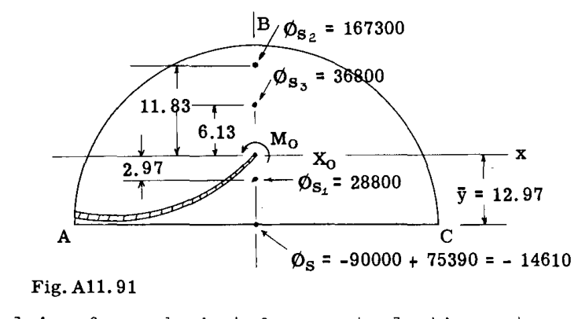

Fig. A11.91

弾性中心における不静定力について解く。

$$M_o = \frac{-\sum \phi_s}{\sum ds/I} = \frac{-218290}{92.83} = -2356$$

$$X_o = \frac{\sum \phi_s y}{I_x} = \frac{167300 \times 11.83 + 36800 \times 6.13 + 28800(-2.97) - 14610(-12.97)}{12713} = 181 \text{ lb.}$$

部材 AC または ABC 上の任意の点における曲げモーメントは、Fig. A11.90 の値に、Fig. A11.91 の $M_o$ および $X_o$ によるものを加えたものに等しくなる。

したがって、部材 ABC 上の点 A において、

$$M_{ABC} = 584 - 2356 + 181 \times 12.97 = 584 \text{ in. lb.}$$

これは、モーメント分配プロセスによって求められたものと同じである。

アーチ上の点 B において：

Fig. A11.90 からの $M_B = 584 + 4000 = 4584$

Fig. A11.91 からの $M_B = -2356 - 181 \times (30 - 12.97) = -5476$

したがって、 $M_B = 4584 - 5476 = -892 \text{ in. lb.}$

## 節点変位を持つ構造物

非対称フレーム、または非対称に荷重が加えられたフレームの場合、節点の回転のみが発生するという仮定は、結果として生じるモーメントにかなりの誤差を与える可能性がある。節点の移動は、直線部材で構成されるフレームについて以前に説明し説明したのと同様の方法で処理できる。

フレーム境界上の外板支持力の分配は、通常、後で説明するように、曲げにおけるシェルの剪断流分配に従うものとされる。

## A11.20 問題 *

1. Figs. 1 から 6 に示されている荷重構造物の曲げモーメント図を求めよ。
2. Figs. 7 から 10 に示されている荷重構造物のすべての節点および支持点における曲げモーメントを求めよ。
3. Fig. 11 の荷重梁において、エレベーター梁の支持部 B と E が、支持部 C と D よりも 0.1 インチ多く沈下している。支持部における結果としての曲げモーメントを計算し、反力を求めよ。 $EI = 320,000 \text{ lb. in. sq.}$
4. Fig. 12 は、 $20 \text{ lb./in.}$ の均一な空気荷重を支持する連続 3 スパン翼梁を示している。ストラット点 A および B における梁の曲げモーメントを決定せよ。  
   $I_{AB} = 17 \text{ in.}$ , $I_{AA'} = 20 \text{ in.}$ , $E = 1.3 \times 10^6 \text{ in.}^2$ とする。  
   ストラットの軸変形による支持たわみの影響は無視せよ。
5. Figs. 13 から 15 は、節点移動を受ける荷重構造物である。曲げモーメント図を決定せよ。
- 第 C2 章、パート F、L、M、および Q も参照。